# PEC GSE183325 RNASeq Analysis

Jason Lubega

06.Mar.2025

## Background

Myelodysplastic syndromes (MDS) are clonal hematopoietic stem cell (HSC) malignancies characterized by ineffective hematopoiesis with increased incidence in elderly individuals. Genetic alterations do not fully explain the molecular pathogenesis of the disease, indicating that other types of lesions may play a role in its development. In this work, we will analyze the transcriptional lesions of human HSCs to explore how aging and MDS are characterized.

MDS Young vs Elderly

## Plan

#### Set working directory

```r
setwd("C:/Users/Lenovo/MIB Assignments/NOTES/Bioinformatica/Bioinformatics Practice R/PEC GSE183325 NereaB")
```

#### Load libraries

```r
#Getting GEOData
library(Biobase)
library(GEOquery)

#EDA, DEA packages
library(edgeR)
library(limma)
library(DESeq2)

#Data visualisation
library(ggplot2)
library(ggrepel)
suppressPackageStartupMessages(library(ComplexHeatmap))

#Data manipulation
library(tidyverse)
library(dplyr)
library(reshape2)

##****** Human gene annotation package
#if (!require("BiocManager", quietly = TRUE))
    #install.packages("BiocManager")
#BiocManager::install("org.Hs.eg.db")

library(org.Hs.eg.db)

#BiocManager::install("biomaRt")
library(biomaRt)

#BiocManager::install("AnnotationDbi")
library(AnnotationDbi)
```

#### Load Data

Loading metadata files from GEO and Raw Counts (locally)

```r
#counts data
counts_rawdata <- read.csv('GSE183325_RawCounts_matrix_Young_Elderly_MDS.csv' , sep = "", header = TRUE)

#View(counts_rawdata)

#ATTEMPT 2 on sample Metadata
library(GEOquery)

GSE183325_allmetadata <- getGEO("GSE183325", GSEMatrix = TRUE)
```

```
Found 1 file(s)
GSE183325_series_matrix.txt.gz
Using locally cached version: C:\Users\Lenovo\AppData\Local\Temp\RtmpctDvES/GSE183325_series_matrix.txt.gz
Using locally cached version of GPL18573 found here:
C:\Users\Lenovo\AppData\Local\Temp\RtmpctDvES/GPL18573.soft.gz
```

```r
#this is a list that contains all sections
#I am interested in the "phenoData" and the "featureData"

#Expression DataSet extraction

# Store the GEO dataset as "GSE60450_gse"
GSE183325_gse <- GSE183325_allmetadata[[1]]

# Get the names of samples
sample_id <- sampleNames(GSE183325_gse)
#View(sample_id)

# Get the expression matrix
View(exprs(GSE183325_gse))

#samples metadata
sample_metadata <- pData(GSE183325_gse)
#View(sample_metadata)

#Changing column headings to sample Names
#colnames(counts_rawdata) == rownames(sample_metadata) #ALL TRUE
colnames(counts_rawdata) <- rownames(sample_metadata) #success
```

**Obtaining gene metadata - GENE MAPPING**

We don’t have a gene metadata file. Therefore we created one using the ENSEMBL Gene IDs in the counts data. This requires us to first convert ENSEMBL Gene IDs to ENTREZ Gene IDs

**org.Hs.eg.db vs biomaRt**

In order to obtain the gene metadata, I performed gene mapping using both *biomaRt* and *org.Hs.eg.db*.

**org.Hs.eg.db**

```r
#GETTING gene_metadata #***********

#* Using org.Hs.eg.db
#columns(org.Hs.eg.db)

ensembl_geneIDs <- rownames(counts_rawdata)
#View(ensembl_geneIDs)

entrez_geneIDS <- mapIds(org.Hs.eg.db, keys = ensembl_geneIDs, column = "ENTREZID", keytype = "ENSEMBL", multiVals = "first")
entrez_geneIDS_df <- data.frame(entrez_geneIDS)
colnames(entrez_geneIDS_df) <- c("ENTREZID")

#View(entrez_geneIDs_df)

gene_metadata_annotated <- select(org.Hs.eg.db,keys=entrez_geneIDS_df$ENTREZID,columns=c("ENTREZID","SYMBOL","GENENAME"))
#entrez_geneIDS_df$ENTREZID == gene_metadata_annotated$ENTREZID #TRUE

rownames(gene_metadata_annotated) <- rownames(entrez_geneIDS_df) #success

#renamed rownames of the gene_metadata_annotated file to contain ENSEMBL gene IDs as some genes lack the Entrez ID.

head(gene_metadata_annotated)
```

|  | ENTREZID | SYMBOL | GENENAME |
| --- | --- | --- | --- |
| ENSG00000223972 | NA | NA | NA |
| ENSG00000227232 | NA | NA | NA |
| ENSG00000278267 | 102466751 | MIR6859-1 | microRNA 6859-1 |
| ENSG00000243485 | NA | NA | NA |
| ENSG00000284332 | 100302278 | MIR1302-2 | microRNA 1302-2 |
| ENSG00000237613 | 645520 | FAM138A | family with sequence similarity 138 member A |

```r
NA
```

Alot of N/A s Unannotated genes therefore we will try again with biomaRt.

**biomaRt**

```r
#********BIOMART gene mapping

#Therefore we will turn to using biomaRt instead
#As it contains the updated ensembl data.

ensembl <- useEnsembl(biomart = "genes", dataset = "hsapiens_gene_ensembl")

# Query Ensembl for gene symbols
# We will use the "ensembl_geneIDs" object created in the previous chunk.

gene_mapping <- getBM(
  attributes = c("ensembl_gene_id","entrezgene_id", "hgnc_symbol","description"),
  filters = "ensembl_gene_id",
  values = ensembl_geneIDs,
  mart = ensembl
)

#Are the rownames in the same order as our gene metadata file???
#gene_mapping$ensembl_gene_id==rownames(gene_metadata_annotated) #FALSE

 # View results
head(gene_mapping)
```

|  | ensembl_gene_id | entrezgene_id | hgnc_symbol | description |
| --- | --- | --- | --- | --- |
| 1 | ENSG00000000457 | 57147 | SCYL3 | SCY1 like pseudokinase 3 [Source:HGNC Symbol;Acc:HGNC:19285] |
| 2 | ENSG00000000460 | 55732 | FIRRM | FIGNL1 interacting regulator of recombination and mitosis [Source:HGNC Symbol;Acc:HGNC:25565] |
| 3 | ENSG00000000938 | 2268 | FGR | FGR proto-oncogene, Src family tyrosine kinase [Source:HGNC Symbol;Acc:HGNC:3697] |
| 4 | ENSG00000000971 | 3075 | CFH | complement factor H [Source:HGNC Symbol;Acc:HGNC:4883] |
| 5 | ENSG00000001460 | 90529 | STPG1 | sperm tail PG-rich repeat containing 1 [Source:HGNC Symbol;Acc:HGNC:28070] |
| 6 | ENSG00000001461 | 57185 | NIPAL3 | NIPA like domain containing 3 [Source:HGNC Symbol;Acc:HGNC:25233] |

```r
NA
```

```r
gene_mapping_backup <- gene_mapping #unmodified gene mapping data
#from now non gene_mapping will be modified to suit my data

gene_mapping_annotated <- gene_mapping[match(rownames(gene_metadata_annotated), gene_mapping$ensembl_gene_id), ]


library(dplyr)

gene_mapping <- gene_mapping %>%
  group_by(ensembl_gene_id) %>%
  summarise(hgnc_symbol = paste(unique(hgnc_symbol), collapse = "; "))  # Merge duplicate symbols

rownames(gene_mapping) <- gene_mapping$ensembl_gene_id

#Since gene_mapping lacks the other important rows we will add them from gene_mapping_annotated

gene_mapping_combined <- full_join(gene_mapping, gene_mapping_annotated,
                                   by = "ensembl_gene_id")
head(gene_mapping_combined)
```

| ensembl_gene_id | hgnc_symbol.x | entrezgene_id | hgnc_symbol.y | description |
| --- | --- | --- | --- | --- |
| ENSG00000000003 | TSPAN6 | 7105 | TSPAN6 | tetraspanin 6 [Source:HGNC Symbol;Acc:HGNC:11858] |
| ENSG00000000005 | TNMD | 64102 | TNMD | tenomodulin [Source:HGNC Symbol;Acc:HGNC:17757] |
| ENSG00000000419 | DPM1 | 8813 | DPM1 | dolichyl-phosphate mannosyltransferase subunit 1, catalytic [Source:HGNC Symbol;Acc:HGNC:3005] |
| ENSG00000000457 | SCYL3 | 57147 | SCYL3 | SCY1 like pseudokinase 3 [Source:HGNC Symbol;Acc:HGNC:19285] |
| ENSG00000000460 | FIRRM | 55732 | FIRRM | FIGNL1 interacting regulator of recombination and mitosis [Source:HGNC Symbol;Acc:HGNC:25565] |
| ENSG00000000938 | FGR | 2268 | FGR | FGR proto-oncogene, Src family tyrosine kinase [Source:HGNC Symbol;Acc:HGNC:3697] |

```r
#**** gene_mapping_annotated has all IDs but some are duplicated
#* gene_mapping has unique ensembl Ids (no duplications)
#*
#*

gene_mapping_metadata_COMPLETE <- merge.data.frame(gene_metadata_annotated, gene_mapping_annotated, by.x=0, by.y="ensembl_gene_id" )

#** gene_mapping_metadata_COMPLETE has is the BEST gene metadata set as it contains all fields from both "org.Hs.eg.db" and "BiomaRt"
```

## **Exploratory Data Analysis (EDA)**

### Raw Counts vs Normalised Counts

**Data filtering**

I will use filterByExpr() function with a default parameters. The default parameters exclude a lot of genes as seen below.

myge_filter  
FALSE TRUE  
42022 16713

**Attempt 2** with min.count = 5 and min.total.count = 10

myge_filter  
FALSE=39988, TRUE = 18747

However, I will use the default method as the difference is not substantial.

```r
colSums(counts_rawdata)
```

```
GSM5555624 GSM5555625 GSM5555626 GSM5555627 GSM5555628 GSM5555629
   9574164   11920687    8180148   12658099    9313956   16566230
GSM5555630 GSM5555631 GSM5555632 GSM5555633 GSM5555634 GSM5555635
  14629096   17148314   18419609    4850472   35693308    5828677
GSM5555636 GSM5555637 GSM5555638 GSM5555639 GSM5555640 GSM5555641
   8408602    9534604   12582022   12237806   14405163   14757819
GSM5555642 GSM5555643 GSM5555644 GSM5555645 GSM5555646 GSM5555647
   9558698   17372396    6134480    8889445   11429387   14856733
GSM5555648 GSM5555649 GSM5555650 GSM5555651 GSM5555652 GSM5555653
  22658051    7179192   24076622    7936673    5437539   11603870
GSM5555654 GSM5555655 GSM5555656 GSM5555657 GSM5555658 GSM5555659
   5001522    9345469   10519754   14113136   11219612   15881674
GSM5555660
  18063192
```

```r
group_age <- sample_metadata$`condition:ch1`

table(group_age)
```

```
group_age
Elderly healthy donor Untreated MDS patient   Young healthy donor
                    8                    12                    17
```

```r
#creating filtering criteria
library(edgeR)

myge_filter <- filterByExpr(counts_rawdata, group = group_age, min.count = 10, min.total.count = 15)

#table(myge_filter)

## Using filter to keep only TRUE values
counts_raw_filtered <- counts_rawdata[myge_filter,]
#dim(counts_raw_filtered) #success [1] 16713  by  37
```

**Normalized Counts**

Using TMM normalisation  
normLibSizes()  
What method does DeSeq2 analysis need?

```r
#tmm normalization - requires edgeR library

dge <- DGEList(counts = counts_raw_filtered, group= group_age)


norm_counts <-  normLibSizes(dge, method = "TMM")
counts_normalized <- cpm(norm_counts, normalized.lib.sizes = TRUE)

counts_norm_log2 <- log2(counts_normalized+1)
```

**Depth Chart (Raw vs Normalised)**

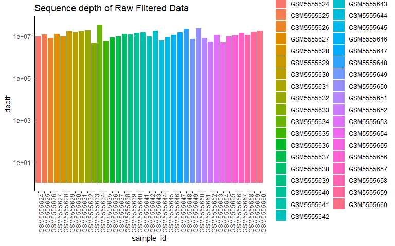

```r
par(mfrow = c(1, 2))

p_raw
```

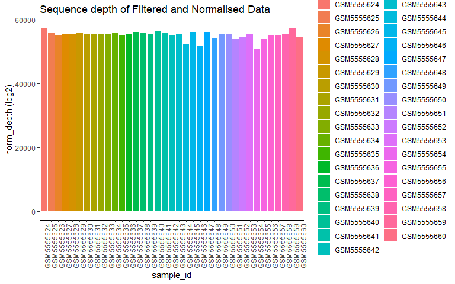

```r
p_norm

par(mfrow = c(1, 1))
```

**Distribution Chart (Raw vs Normalised)**

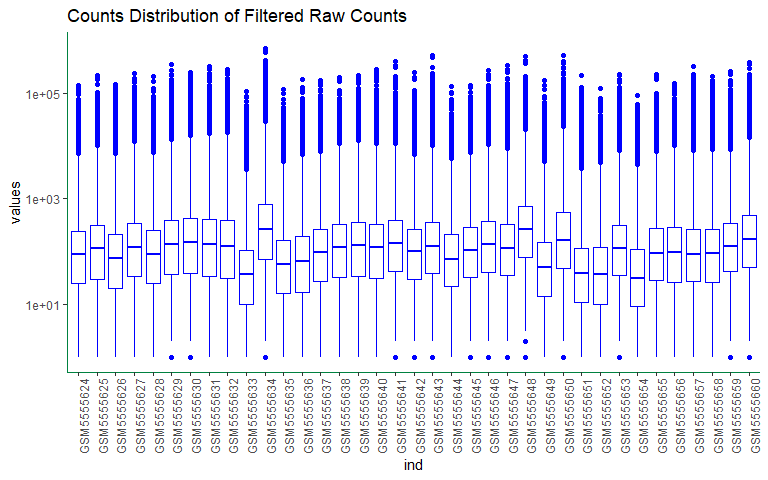

```r
par(mfrow = c(2, 1))

bp_raw
```

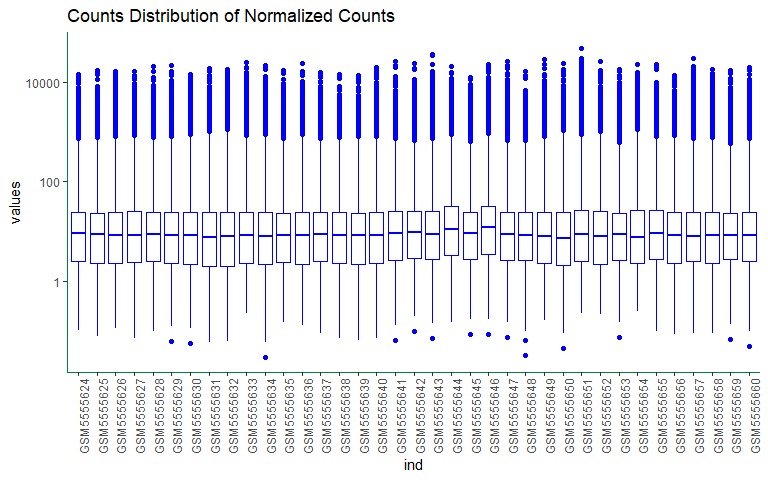

```r
bp_norm

par(mfrow = c(1, 1))
```

**Principal Component Analysis - PCA Plot**

Check variance in the dataset. Anomalies or Outliers.

I used the normalized Counts data

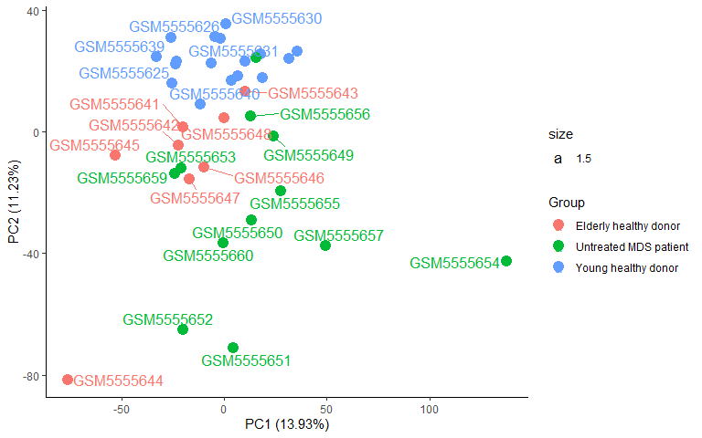

```r
## Principal component Analysis

pca_output <- prcomp(t(counts_norm_log2))
# to compute for samples we need to provide it by rows
# so we transpose our matrix.

pca_df <- data.frame(PC1=pca_output$x[,1],
                     PC2=pca_output$x[,2],
                     Group=group_age)

ggplot(pca_df,aes(x=PC1, y=PC2, color=Group)) +
  geom_point(size=4) +
  theme_classic() +
  xlab("PC1 (13.93%)") +
  ylab("PC2 (11.23%)")+
  geom_text_repel(aes(label=rownames(pca_df), size=1.5))
```

## **Differential Gene Expression (DEA)**

What parameter are we contrasting by?

*Young vs Elderly*

*Healthy vs Untreated MDS*

Method: DeSeq2

#### DESeq2

```r
######### DESeq2 #########
library(dplyr)

# Include the group variable as a factor

sample_metadata$group <- factor(dplyr::recode(sample_metadata$`condition:ch1`,
                                              "Young healthy donor"="Young_healthy",
                                              "Elderly healthy donor"="Elderly_healthy", "Untreated MDS patient" = "MDS_Untreated"),
                                        levels=c("Young_healthy","Elderly_healthy","MDS_Untreated"))

#Also include group2 of Healthy vs MDS sick.
sample_metadata$group2 <- factor(dplyr::recode(sample_metadata$`condition:ch1`,
                                              "Young healthy donor"="Healthy",
                                              "Elderly healthy donor"="Healthy", "Untreated MDS patient" = "MDS_Untreated"),
                                        levels=c("Healthy","MDS_Untreated"))

# Create DESeqDataSet object with count data, sample metadata, and design matrix
library("DESeq2")
dds <- DESeqDataSetFromMatrix(countData = counts_rawdata,
                              colData = sample_metadata,
                              design = ~ 0 + group)
#View(dds)

# Filter out low expressed genes

dds.filt <- dds[myge_filter,]

dim(dds.filt) #[1] 16713    37
```

```
[1] 16713    37
```

```r
# Differential expression analysis
dds.filt.dea <- DESeq(dds.filt)
```

```
-- replacing outliers and refitting for 103 genes
-- DESeq argument 'minReplicatesForReplace' = 7
-- original counts are preserved in counts(dds)
```

```r
##########################
```

#### Results:DESEq2

**Significantly Differentially Expressed Genes**

log2FoldChange >0.58 & padj<=0.05

Biological significance vs Statistical Significance.

```r
res <- results(dds.filt.dea) # shows the contrast by default based on group factor order.

saveRDS(res, "DEA_DESeq2_GSE183325.rds")

#dim(res) #[1] 16713     6

#***SIGNIFICANTLY DEA Genes***

sig_Genes <- res[res$padj<=0.05 & res$log2FoldChange>0.58, ]
sig_Genes <- data.frame(sig_Genes)
head(sig_Genes)
```

|  | baseMean | log2FoldChange | lfcSE | stat | pvalue | padj |
| --- | --- | --- | --- | --- | --- | --- |
| ENSG00000227232 | 659.2468 | 1.870551 | 0.2542633 | 7.356747 | 1.884465e-13 | 2.422697e-10 |
| ENSG00000268903 | 696.4985 | 1.246061 | 0.2922802 | 4.263240 | 2.014839e-05 | 8.173303e-04 |
| ENSG00000279457 | 403.0729 | 1.266714 | 0.2575065 | 4.919154 | 8.691924e-07 | 6.917530e-05 |
| ENSG00000250575 | 243.4121 | 1.047154 | 0.3031055 | 3.454751 | 5.508010e-04 | 9.609121e-03 |
| ENSG00000229344 | 1281.6160 | 1.385618 | 0.4898577 | 2.828614 | 4.675000e-03 | 4.142804e-02 |
| ENSG00000228327 | 781.0342 | 0.813953 | 0.2201916 | 3.696567 | 2.185342e-04 | 4.812072e-03 |

```r
#dim(sig_Genes) #[1] 1346    6
```

**8.05%**

> Therefore *1346* genes out of the filtered *16713* are statisticaly and biologically significant.

### DEA visualization plots

**Volcano Plot**

Biological significance vs Statistical Significance

[figure not shown]

```r
#Volcano Plot

#I used the res object (consult if it was the appropriate choice)

ggplot(res, aes(x = log2FoldChange, y = -log10(padj))) +
  # All genes = BLACK (These don't change)
  geom_point(color = "black", alpha = 0.3) +

  #Overexpressed genes = RED
  geom_point(data=res[res$log2FoldChange > 0.58 & res$padj <= 0.05,],
             aes(x = log2FoldChange, y = -log10(padj)), color="red", alpha = 0.7) +

  #Under expressed genes = BLUE
  geom_point(data=res[res$log2FoldChange < -0.58 & res$padj <= 0.05,],
             aes(x = log2FoldChange, y = -log10(padj)), color="blue", alpha = 0.7) +

#ref lines
  geom_hline(yintercept = -log10(0.05), linetype = "dashed", color = "blue") +
  geom_vline(xintercept = c(0.58, -0.58), linetype = "dashed", color = "gray") +

  theme_minimal() +

  labs(title = "Volcano Plot - Differential Expression",
       x = "Log2 Fold Change",
       y = "-Log10 adj-P-value")
```

RED dots = Differentially Overexpressed genes.

BLUE dots = Differentially Underexpressed genes.

#### **Heatmap Top 50 genes (Labeled with Gene SYMBOLS)**

I tried to replace the ENSEMBL IDs with Gene Symbols, however, the matching was erroneous when **%in%** was used. I resolved this by using **match()** instead of **%in%**.

And I have randomly checked for rownames in my annotated object vs “SYMBOL” in the gene_metadata file to proof read.

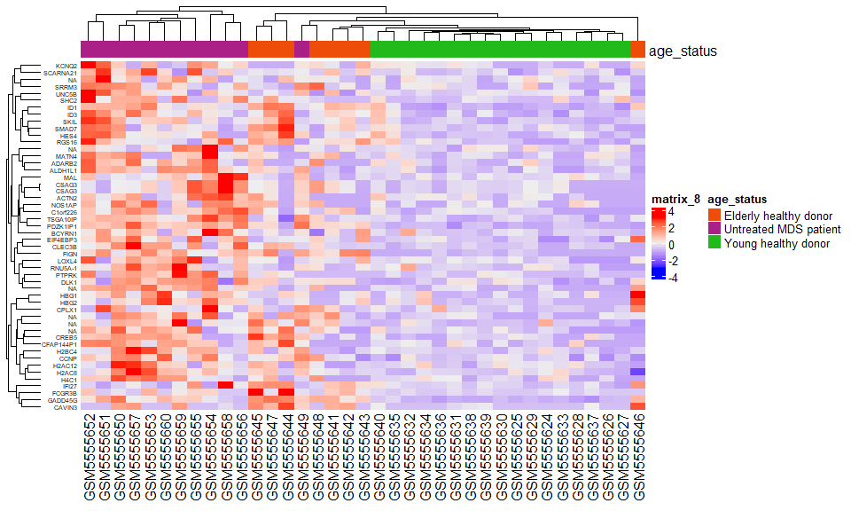

#### **COMPARISONS and CONTRASTS**

**DDIT3 across age and health status**  
symbol: DDIT3  
ensembl: ENSG00000175197  
Description: DNA damage inducible transcript 3

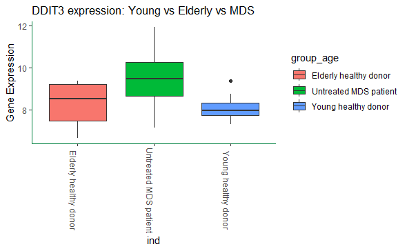

```r
grouped_samples <- sample_metadata[,c("geo_accession", "condition:ch1")]
View(grouped_samples)

young_ids <- grouped_samples$geo_accession[grouped_samples$`condition:ch1`=="Young healthy donor"]

elderly_ids <- grouped_samples$geo_accession[grouped_samples$`condition:ch1`=="Elderly healthy donor"]

mds_ids <- grouped_samples$geo_accession[grouped_samples$`condition:ch1`== "Untreated MDS patient"]

healthy_ids <- c(young_ids,elderly_ids) #healthy ids both Young and Elderly

##** grouped_samples add a column for Healthy, MDS Sick

grouped_samples$status <- c("Healthy", "Healthy", "Healthy","Healthy","Healthy","Healthy","Healthy","Healthy","Healthy","Healthy","Healthy","Healthy","Healthy","Healthy","Healthy","Healthy","Healthy","Healthy","Healthy","Healthy","Healthy","Healthy","Healthy","Healthy","Healthy", "MDS", "MDS","MDS","MDS","MDS","MDS","MDS","MDS","MDS","MDS","MDS","MDS")

###****

ddit3_boxplot_data <- as.data.frame(t(dds.filt.dea_norm["ENSG00000175197", c(young_ids, elderly_ids, mds_ids)]))

#View(ddit3_boxplot_data)

ddit3_boxplot_data <- cbind(t(ddit3_boxplot_data),  grouped_samples[,c("condition:ch1", "status")])


#change colnames
colnames(ddit3_boxplot_data) <- c("norm_counts", "ind", "status")

#str(ddit3_boxplot_data) #oops even the values are characters!!

ddit3_boxplot_data <- as.data.frame(ddit3_boxplot_data)  # Convert to data frame
ddit3_boxplot_data$norm_counts <- as.numeric(ddit3_boxplot_data$norm_counts)  # Convert to numeric

#plot
ggplot(ddit3_boxplot_data, aes(x=ind, y=norm_counts, fill=group_age)) +
  ggtitle("DDIT3 expression: Young vs Elderly vs MDS")+
  geom_boxplot(size = 0.5) +
  theme_classic() +
  theme(axis.text.x = element_text(angle=270), axis.line = element_line(color = "#008140"))+
  ylab("Gene Expression")
```

DDIT3, is overexpressed in MDS Untreated patients.

**DDIT3 in Healthy vs MDS**  
Here, the young and elderly donors were combined to form a healthy population to compare with the sick (Untreated MDS patients).

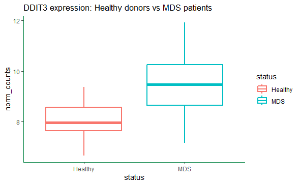

```r
ggplot(ddit3_boxplot_data, aes(x=status, y=norm_counts, color=status)) +
  ggtitle("DDIT3 expression: Healthy donors vs MDS patients")+
  geom_boxplot(size = 1) +
  theme_classic() +
  theme(axis.text.x = element_text(angle=360), axis.line = element_line(color = "#008140"))
```

> Untreated MDS patients express higher DDIT3 levels than both healthy young and elderly populations. Hence MDS could be characterised by a higher occcurence of DNA damage pathways.

#### **SOMATIC MUTATIONS**

Broadly, the most common genes with recurrent somatic mutations in MDS include **ASXL1** (10–20%), EZH2 (5–10%), NRAS (5–10%), **RUNX1** (10–15%), **SF3B1** (20–30%), **SRSF2** (10–15%), STAG2 (5–10%), **TET2** (20–30%), **TP53** (10–12%), and U2AF1 (5–12%).

For this, I will only check those that have an occurrence greater than 10% (in Bold).

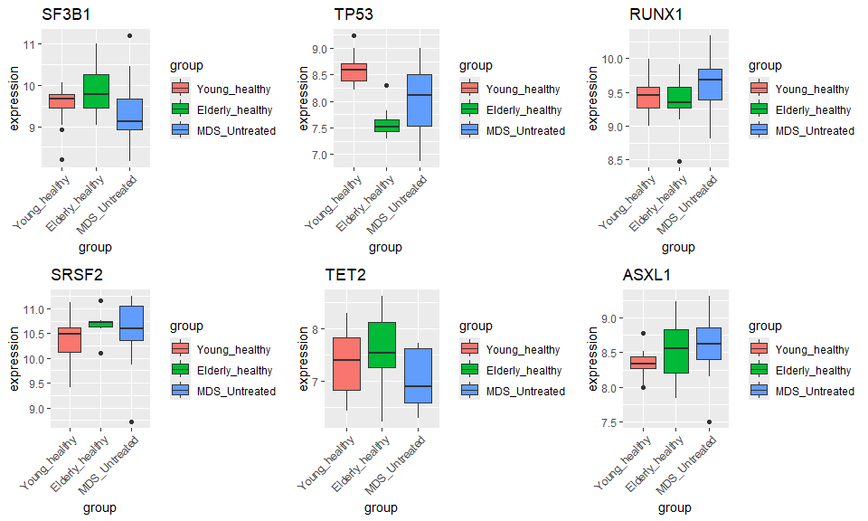

#### **MORE Comparisons and Contrasts**

```r
#COMPARISONS and CONTRASTS
# To get the changes for each comparison we need to define a contrast

Young_vs_Elderly_DESeq2 <- results(dds.filt.dea, contrast=c("group", "Young_healthy", "Elderly_healthy"))

Healthy_Yg_vs_MDS_DESeq2 <- results(dds.filt.dea, contrast=c("group", "Young_healthy", "MDS_Untreated"))

Healthy_El_vs_MDS_DESeq2 <- results(dds.filt.dea, contrast=c("group", "Elderly_healthy", "MDS_Untreated"))

#Healthy_yg_El_vs_MDS <- results(dds.filt.dea, contrast=c("group2", "Healthy", "MDS_Untreated")) #This  comparison needs its own DEA model matrix. Its group is  **dds.filt.dea$group2**

# Save in a list including the gene info
DEA_output <- list(Young_vs_Elderly=merge(data.frame(Young_vs_Elderly_DESeq2),gene_mapping_metadata_COMPLETE,by.x=0, by.y="Row.names"),
                   Healthy_Yg_vs_MDS=merge(data.frame(Healthy_Yg_vs_MDS_DESeq2),gene_mapping_metadata_COMPLETE,by.x=0, by.y="Row.names"),
                   Healthy_El_vs_MDS=merge(data.frame(Healthy_El_vs_MDS_DESeq2),gene_mapping_metadata_COMPLETE,by.x=0, by.y="Row.names"))


#colnames(gene_mapping_metadata_COMPLETE)
#View(Healthy_Yg_vs_MDS_DESeq2)

#****** It MERGED SUCCESSFULLY...

#****** PLAN B

#1-yOUNG healthy vs ELDERLY healthy

result_yg_vs_El_DF <- data.frame(Young_vs_Elderly_DESeq2)

Young_vs_Elderly_DESeq2_metadata <- gene_metadata_annotated[rownames(gene_metadata_annotated) %in% rownames(result_yg_vs_El_DF), c("SYMBOL", "GENENAME")]

Young_vs_Elderly_DESeq2_annotated  <- cbind(result_yg_vs_El_DF, Young_vs_Elderly_DESeq2_metadata) #success

#head(Young_vs_Elderly_DESeq2_annotated[order(Young_vs_Elderly_DESeq2_annotated$log2FoldChange, decreasing = TRUE),]) #check


#2-yOUNG healthy vs MDS Untreated Patient

result_yg_vs_MDS_DF <- data.frame(Healthy_Yg_vs_MDS_DESeq2)

Healthy_Yg_vs_MDS_DESeq2_metadata <- gene_metadata_annotated[rownames(gene_metadata_annotated) %in% rownames(result_yg_vs_MDS_DF), c("SYMBOL", "GENENAME")]

Healthy_Yg_vs_MDS_DESeq2_annotated  <- cbind(result_yg_vs_MDS_DF, Healthy_Yg_vs_MDS_DESeq2_metadata) #success


#3-ELDERLY healthy vs MDS Untreated Patient

result_El_vs_MDS_DF <- data.frame(Healthy_El_vs_MDS_DESeq2)

Healthy_El_vs_MDS_DESeq2_metadata <- gene_metadata_annotated[rownames(gene_metadata_annotated) %in% rownames(result_El_vs_MDS_DF), c("SYMBOL", "GENENAME")]

Healthy_El_vs_MDS_DESeq2_annotated  <- cbind(result_El_vs_MDS_DF, Healthy_El_vs_MDS_DESeq2_metadata) #success
```

**Visualizing contrasts**

**Healthy: Young vs Elderly**

*Top 5 Over and Underexpressed*

```r
# Prepare a joint data frame with the data to plot

contrasts_to_plot <- data.frame(gene=rownames(Young_vs_Elderly_DESeq2_annotated),
                           log2FC_yg_vs_El=Young_vs_Elderly_DESeq2_annotated$log2FoldChange,
                           padj_yg_vs_El = Young_vs_Elderly_DESeq2_annotated$padj,
                           log2FC_yg_vs_MDS=Healthy_Yg_vs_MDS_DESeq2_annotated$log2FoldChange,
                           padj_yg_vs_MDS = Healthy_Yg_vs_MDS_DESeq2_annotated$padj,
                           log2FC_El_vs_MDS=Healthy_El_vs_MDS_DESeq2_annotated$log2FoldChange,
                            padj_El_vs_MDS = Healthy_El_vs_MDS_DESeq2_annotated$padj)

#*****young vs elderly PLOT

#Order this dataframe according to fold change

yg_vs_el_plot_ordFch <- contrasts_to_plot[,c("gene", "log2FC_yg_vs_El", "padj_yg_vs_El")]

#Order by Fc from Big to Small
yg_vs_el_plot_ordFch <- yg_vs_el_plot_ordFch[order(yg_vs_el_plot_ordFch$log2FC_yg_vs_El, decreasing = TRUE),]

#Putting these in the same plot (5 of each)
yg_el_five_ordFch <- rbind(yg_vs_el_plot_ordFch[1:5, ], tail(yg_vs_el_plot_ordFch, n=5) )

yg_el_five_ordFch <- yg_el_five_ordFch %>%
  mutate(expression = ifelse(log2FC_yg_vs_El > 0, "UP", "DOWN"))

yg_el_five_ordFch$hgnc_symbol <- gene_mapping_metadata_COMPLETE[match(yg_el_five_ordFch$gene, gene_mapping_metadata_COMPLETE$Row.names), c("hgnc_symbol") ]

ggplot(data = yg_el_five_ordFch , mapping=aes(x=hgnc_symbol, y=log2FC_yg_vs_El, fill = expression)) +
  ggtitle("Young vs Elderly: Top 5 Overexpressed & Underexpressed genes")+
  geom_col()+
  scale_fill_manual(values = c("UP" = "red", "DOWN" = "blue")) +
  coord_flip() +
  theme(axis.text.x = element_text(angle = 90,hjust=1))
```

[output not shown]

**Young Healthy vs MDS**  
Top 5 over expressed and top 5 Underexpressed.

Here, we would like to retrieve 10 overexpressed genes and 10 Underexpressed genes between the Healthy donors and the Sick Untreated MDS patients.

Therefore we would have to perform a contrast between the two populations.

```r
#++++ Young HEALTHY VS MDS (PLOT) ++++#

#Order this dataframe according to fold change
#Order by Fc from Big to Small

yg_vs_MDS_plot_ordFch <- contrasts_to_plot[,c("gene", "log2FC_yg_vs_MDS")]

yg_vs_MDS_plot_ordFch <- yg_vs_MDS_plot_ordFch[order(yg_vs_MDS_plot_ordFch$log2FC_yg_vs_MDS, decreasing = TRUE),]

#Putting these in the same plot (5 of each)
yg_MDS_five_ordFch <- rbind(yg_vs_MDS_plot_ordFch[1:5, ], tail(yg_vs_MDS_plot_ordFch, n=5) )

yg_MDS_five_ordFch <- yg_MDS_five_ordFch %>%
  mutate(expression = ifelse(log2FC_yg_vs_MDS > 0, "UP", "DOWN"))

yg_MDS_five_ordFch$hgnc_symbol <- gene_mapping_metadata_COMPLETE[match(yg_MDS_five_ordFch$gene, gene_mapping_metadata_COMPLETE$Row.names), c("hgnc_symbol") ]

ggplot(data = yg_MDS_five_ordFch , mapping=aes(x=hgnc_symbol, y=log2FC_yg_vs_MDS, fill = expression)) +
  geom_col()+
  scale_fill_manual(values = c("UP" = "red", "DOWN" = "blue")) +
  coord_flip() +
  ggtitle("Young vs MDS: Top 5 Overexpressed vs Underexpressed genes")+
  theme(axis.text.x = element_text(angle = 90,hjust=1))
```

[output not shown]

**Elderly Healthy vs MDS**  
In the PCA plot, the elderly samples seemed closely similar to the MDS samples, therefore this contrast will help us identify the differences between these two populations.

**Top 5 Overexpressed vs Bottom 5 Underexpressed**

```r
#++++ Elderly HEALTHY VS MDS (PLOT) ++++#

#Order this dataframe according to fold change
#Order by Fc from Big to Small

El_vs_MDS_plot_ordFch <- contrasts_to_plot[,c("gene", "log2FC_El_vs_MDS")]

El_vs_MDS_plot_ordFch <- El_vs_MDS_plot_ordFch[order(El_vs_MDS_plot_ordFch$log2FC_El_vs_MDS, decreasing = TRUE),]

#Putting these in the same plot (5 of each)
El_MDS_five_ordFch <- rbind(El_vs_MDS_plot_ordFch[1:5, ], tail(El_vs_MDS_plot_ordFch, n=5))

El_MDS_five_ordFch <- El_MDS_five_ordFch %>% mutate(expression = ifelse(log2FC_El_vs_MDS>0, "UP", "DOWN"))

El_MDS_five_ordFch$hgnc_symbol <- gene_mapping_metadata_COMPLETE[match(El_MDS_five_ordFch$gene, gene_mapping_metadata_COMPLETE$Row.names), c("hgnc_symbol") ]

ggplot(data = El_MDS_five_ordFch , mapping=aes(x=hgnc_symbol, y=log2FC_El_vs_MDS, fill = expression)) +
  geom_col()+
  scale_fill_manual(values = c("UP" = "red", "DOWN" = "blue")) +
  coord_flip() +
  ggtitle("Elderly vs MDS: Top 5 Overexpressed vs Underexpressed genes")+
  theme(axis.text.x = element_text(angle = 90,hjust=1))
```

[output not shown]

**Healthy donors** vs **MDS patients**

However, this comparison needs its own DEA process since only 2 groups are being compared instead of the original 3. Its group has been created and can be seen here **dds.filt.dea$group2**.

> How many genes on average a required to change a process? And in what Proportions?

## **PATHWAY ANALYSIS** (GO: Gene Ontology)

Now that differentially expressed genes have been identified, we will analyse enriched pathways in our data groups. This will help us make biological meaning of the actual changes happening in our data.

There are three known methods for performing the pathway analysis namely; ORA , GSEA , GSVA. We will start with the **Over Representation Analysis (ORA)** method.

#### **ORA GO**

**Young Vs Elderly**

1. Up REGULATED

```r
#  Over Representation Analysis (ORA)
# --------------------------------------------------------------------------

# Define the set of genes to test
# Young vs Elderly

# We are going to assess the up-regulated genes:
sig_UP_regulated_genes <- DEA_output$Young_vs_Elderly[DEA_output$Young_vs_Elderly$padj<0.05 & DEA_output$Young_vs_Elderly$log2FoldChange>0.58,]

#dim(sig_UP_regulated_genes)


# Define the ranked genes list based on logFCh.

sig_UP_regulated_genes <-  sig_UP_regulated_genes[order(sig_UP_regulated_genes$log2FoldChange, decreasing = TRUE),]

head(sig_UP_regulated_genes)

# Keep the UP-regulated genes
up_regulated_genes <- sig_UP_regulated_genes$entrezgene_id


# Perform the ORA based on GO terms

# GO over-representation analysis
ora_go_up <- enrichGO(gene          = up_regulated_genes,
                universe      = DEA_output$Young_vs_Elderly$entrezgene_id,
                OrgDb         = org.Hs.eg.db,
                ont           = "BP",
                pAdjustMethod = "BH",
                pvalueCutoff  = 0.01,
                qvalueCutoff  = 0.05,
                readable      = TRUE)
#ora_go_up
#View(ora_go_up@result)

# Results visualization

layout(matrix(c(1, 2, 3), nrow = 1, ncol = 3, byrow = TRUE))

# Barplot
barplot(ora_go_up, showCategory=10, title ="GO_UP: Young vs Elderly")

# Network
cnetplot(ora_go_up, node_label="category",
               cex.params = list(cex_label_category = 1.2))

cnetplot(ora_go_up, node_label="gene",
               cex.params = list(cex_label_category = 1.2))
```

[output not shown]

2. *Down REGULATED: Young vs Elderly*

```r
# We are going to assess the up-regulated genes:
sig_DOWN_regulated_genes <- DEA_output$Young_vs_Elderly[DEA_output$Young_vs_Elderly$padj<0.05 & DEA_output$Young_vs_Elderly$log2FoldChange< -0.58,]

#dim(sig_DOWN_regulated_genes)
head(sig_DOWN_regulated_genes)

# Define the ranked genes list based on logFCh.
sig_DOWN_regulated_genes <- sig_DOWN_regulated_genes[order(sig_DOWN_regulated_genes$log2FoldChange, decreasing = TRUE),]

head(sig_DOWN_regulated_genes)

# Keep the UP-regulated genes
dw_regulated_genes <- sig_DOWN_regulated_genes$entrezgene_id



# Perform the ORA based on GO terms

# GO over-representation analysis
ora_go_dw <- enrichGO(gene          = dw_regulated_genes,
                universe      = DEA_output$Young_vs_Elderly$entrezgene_id,
                OrgDb         = org.Hs.eg.db,
                ont           = "BP",
                pAdjustMethod = "BH",
                pvalueCutoff  = 0.01,
                qvalueCutoff  = 0.05,
                readable      = TRUE)

#head(ora_go_dw@result)
```

```r
# Results visualization

layout(matrix(c(1, 2, 3), nrow = 1, ncol = 3, byrow = TRUE))

# Barplot
barplot(ora_go_dw, showCategory=10, title ="GO_DOWN: Young vs Elderly")

# Network
cnetplot(ora_go_dw, node_label="category",
               cex.params = list(cex_label_category = 1.2))

cnetplot(ora_go_dw, node_label="gene",
               cex.params = list(cex_label_category = 1.2))
```

[output not shown]

**Young Healthy Vs Untreated MDS**

1. *ORA > Up REGULATED*

```r
#  Over Representation Analysis (ORA)
# --------------------------------------------------------------------------

# Define the set of genes to test
# Young vs MDS

# We are going to assess the up-regulated genes:
sig_UP_regulated_ym_genes <- DEA_output$Healthy_Yg_vs_MDS[DEA_output$Healthy_Yg_vs_MDS$padj<0.05 & DEA_output$Healthy_Yg_vs_MDS$log2FoldChange>0.58,]

#dim(sig_UP_regulated_genes)

# Define the ranked genes list based on logFCh.
sig_UP_regulated_ym_genes <- sig_UP_regulated_ym_genes[order(sig_UP_regulated_ym_genes$log2FoldChange, decreasing = TRUE),]

head(sig_UP_regulated_ym_genes)

# Keep the UP-regulated genes
up_regulated_ym_genes <- sig_UP_regulated_ym_genes$entrezgene_id


# GO over-representation analysis
ora_go_up_ym <- enrichGO(gene          = up_regulated_ym_genes,
                universe      = DEA_output$Healthy_Yg_vs_MDS$entrezgene_id,
                OrgDb         = org.Hs.eg.db,
                ont           = "BP",
                pAdjustMethod = "BH",
                pvalueCutoff  = 0.01,
                qvalueCutoff  = 0.05,
                readable      = TRUE)
#ora_go_up_ym
#View(ora_go_up_ym@result)

# Results visualization

layout(matrix(c(1, 2, 3), nrow = 1, ncol = 3, byrow = TRUE))

# Barplot
barplot(ora_go_up_ym, showCategory=10, title ="GO_UP: Young vs MDS")

# Network
cnetplot(ora_go_up_ym, node_label="category",
               cex.params = list(cex_label_category = 1.2))

cnetplot(ora_go_up_ym, node_label="gene",
               cex.params = list(cex_label_category = 1.2))
```

[output not shown]

**Elderly Healthy Vs Untreated MDS**

*ORA > Up REGULATED*

```r
#  Over Representation Analysis (ORA)
# --------------------------------------------------------------------------

# Define the set of genes to test
# Elderly vs MDS

# We are going to assess the up-regulated genes:
sig_UP_regulated_elm_genes <- DEA_output$Healthy_El_vs_MDS[DEA_output$Healthy_El_vs_MDS$padj<0.05 & DEA_output$Healthy_El_vs_MDS$log2FoldChange>0.58,]

#dim(sig_UP_regulated_genes)

# Define the ranked genes list based on logFCh.
sig_UP_regulated_elm_genes <- sig_UP_regulated_elm_genes[order(sig_UP_regulated_elm_genes$log2FoldChange, decreasing = TRUE),]

head(sig_UP_regulated_elm_genes, n=5)

# Keep the UP-regulated genes
up_regulated_elm_genes <- sig_UP_regulated_elm_genes$entrezgene_id


# Perform the ORA based on GO terms

# GO over-representation analysis
ora_go_up_elm <- enrichGO(gene          = up_regulated_elm_genes,
                universe      = DEA_output$Healthy_El_vs_MDS$entrezgene_id,
                OrgDb         = org.Hs.eg.db,
                ont           = "BP",
                pAdjustMethod = "BH",
                pvalueCutoff  = 0.01,
                qvalueCutoff  = 0.05,
                readable      = TRUE)
#ora_go_up_elm
#View(ora_go_up_elm@result)

# Results visualization

layout(matrix(c(1, 2, 3), nrow = 1, ncol = 3, byrow = TRUE))

# Barplot
barplot(ora_go_up_elm, showCategory=10, title ="GO_UP: Elderly vs MDS")

# Network
cnetplot(ora_go_up_elm, node_label="category",
               cex.params = list(cex_label_category = 1.2))

cnetplot(ora_go_up_elm, node_label="gene",
               cex.params = list(cex_label_category = 1.2))
```

[output not shown]

#### **GSEA - Gene Set Enrichment Analysis**

**GSEA: Young Vs Elderly**

```r
# Young vs Elderly

# Define the ranked genes list based on logFCh.

YgElgeneList <- DEA_output$Young_vs_Elderly$log2FoldChange

names(YgElgeneList) <- DEA_output$Young_vs_Elderly$entrezgene_id
YgElgeneList_ranked <- YgElgeneList[order(YgElgeneList, decreasing = TRUE)]


# Perform the GSEA based on GO terms

gsea_go <- gseGO(geneList     = YgElgeneList_ranked,
              OrgDb        = org.Hs.eg.db,
              ont          = "BP",
              minGSSize    = 100,
              maxGSSize    = 500,
              pvalueCutoff = 0.05,
              verbose      = FALSE)

#View(gsea_go@result)

# Results visualization

layout(matrix(c(1, 2, 3), nrow = 1, ncol = 3, byrow = TRUE))

# Dotplot
dotplot(gsea_go,
        x = "GeneRatio",
        color = "NES",
        size = "p.adjust",
        showCategory=10) + ggtitle("GSEA: Young vs Elderly dotplot")

#Network Plot
cnetplot(gsea_go, node_label="category",
               cex.params = list(cex_label_category = 1.2),
               categorySize="p.adjust", color.params = list(foldChange = YgElgeneList_ranked))

# Treeplot
gsea_go2 <- pairwise_termsim(gsea_go)

treeplot(gsea_go2, showCategory = 10)
```

[output not shown]

## CONCLUSIONS

**EDA** Sample anomalies normalies? No significant anomalies detected. However samples *GSM5555646* and *GSM5555649* are a little bit displaced in the clusters.  
The expression profile of *GSM5555646* a sample from a *Healthy Elderly* donor, has more similarity to the *Young Healthy* donors’ samples…(“Aging well haha”).

Raw counts data contained a total of *58735*, of these *16713* genes were retained after the filtering criteria (edgeR default) was applied.

Of the retained 16713 genes, only *8.05%* (N=1346) genes are statisticaly and biologically significant.

**DEA**

8.05% of the filtered genes (using edgeR default) are significantly differentially expressed(both biologically and statistically).

DDIT3 expression is highest in MDS patients followed by Elderly Healthy donors and lowest in young Healthy donors. Overall, its higher in Untreated MDS patients than in Healthy donors.

**Upregulated Pathways by ORA_GO.**

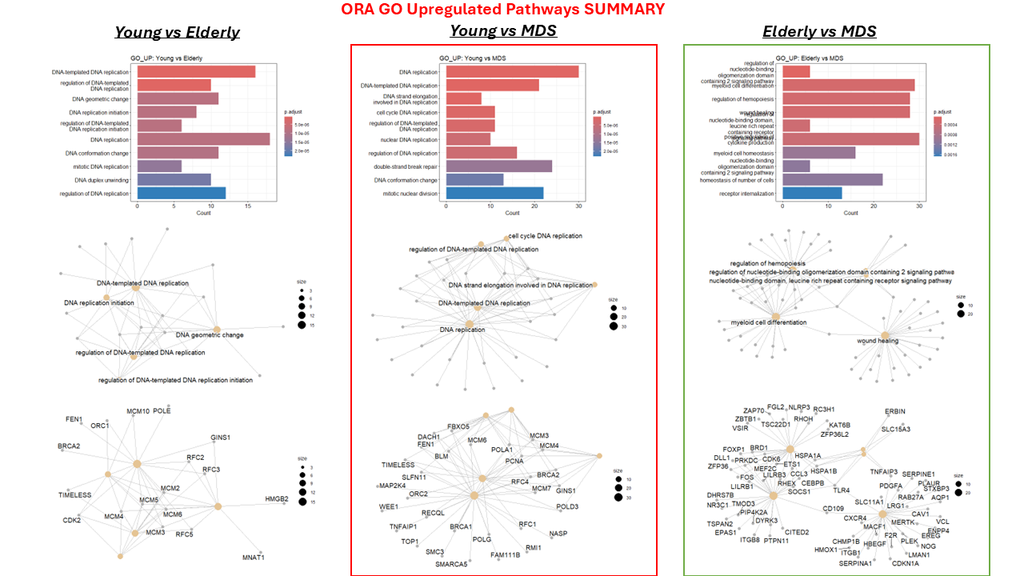

**Enriched pathways via GSEA_GO**

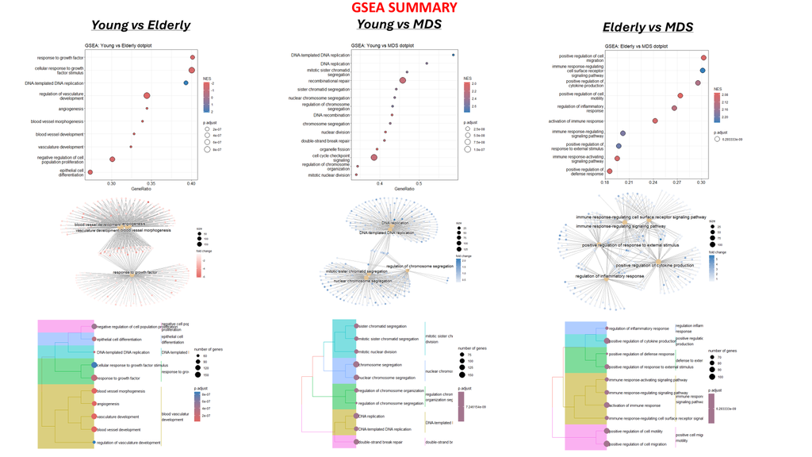

## PROBLEMS ENCOUNTERED

1. Extracting data by rownames from one dataset to another using the **%in%** and **merge** arguments didn’t give a 1:1 pairing (It misaligned the metadata) which in turn leads to obtaining false genes and false pathways. In some cases this was solved by using **match** instead as in the case of the HeatMaps.
2. Correct method for normalising and transforming data (DSEq results) before the *z_transformation* of the Heatmap? **vst** vs **log2(cpm()+1)**! There is a huge difference in the Heatmaps when any of these is used. When *log2(cpm()+1)* was used, there were empty spaces (Grey) in the HeatMap indicating *N/A* values in the z_score.

## References

Berastegui, N., Ainciburu, M., Romero, J. P., Garcia-Olloqui, P., Alfonso-Pierola, A., Philippe, C., Vilas-Zornoza, A., San Martin-Uriz, P., Ruiz-Hernández, R., Abarrategi, A., Ordoñez, R., Alignani, D., Sarvide, S., Castro-Labrador, L., Lamo-Espinosa, J. M., San-Julian, M., Jimenez, T., López-Cadenas, F., Muntion, S., Sanchez-Guijo, F., … Prosper, F. (2022). The transcription factor DDIT3 is a potential driver of dyserythropoiesis in myelodysplastic syndromes. Nature communications, 13(1), 7619. https://doi.org/10.1038/s41467-022-35192-7

Awada, H., Thapa, B., & Visconte, V. (2020). The Genomics of Myelodysplastic Syndromes: Origins of Disease Evolution, Biological Pathways, and Prognostic Implications. Cells, 9(11), 2512. https://doi.org/10.3390/cells9112512

S Xu, E Hu, Y Cai, Z Xie, X Luo, L Zhan, W Tang, Q Wang, B Liu, R Wang, W Xie, T Wu, L Xie, G Yu. Using clusterProfiler to characterize multiomics data. Nature Protocols. 2024, 19(11):3292-3320